# Project: Investigate a Dataset (No_show)

- Introduction
- Data Wrangling
- Exploratory Data Analysis
- Conclusions

# Introduction:

### firstly the project is to investegate the No_show data by cleaning the data, make the analsys, and answering the quistions.

> **Quistion1**: what is the gender that have the highest percentage of no show?

> **Quistion2**: does the Age effecting for no_show?

> **Quistion3**: does the scholarship effecting the no_show?

> **Quistion4**: does sms have huge impact on showing?

> **Quistion5**: which illness type have the highest no-show ratio?

```python
import pandas as pd
import numpy as np
import matplotlib.pyplot as plt
import seaborn as sns
%matplotlib inline
```

## Data Wrangling

### General Properties

```python
p2 = pd.read_csv('Project2.csv')
p2.head()
```

|  | PatientId | AppointmentID | Gender | ScheduledDay | AppointmentDay | Age | Neighbourhood | Scholarship | Hipertension | Diabetes | Alcoholism | Handcap | SMS_received | No-show |
| --- | --- | --- | --- | --- | --- | --- | --- | --- | --- | --- | --- | --- | --- | --- |
| 0 | 2.987250e+13 | 5642903 | F | 2016-04-29T18:38:08Z | 2016-04-29T00:00:00Z | 62 | JARDIM DA PENHA | 0 | 1 | 0 | 0 | 0 | 0 | No |
| 1 | 5.589978e+14 | 5642503 | M | 2016-04-29T16:08:27Z | 2016-04-29T00:00:00Z | 56 | JARDIM DA PENHA | 0 | 0 | 0 | 0 | 0 | 0 | No |
| 2 | 4.262962e+12 | 5642549 | F | 2016-04-29T16:19:04Z | 2016-04-29T00:00:00Z | 62 | MATA DA PRAIA | 0 | 0 | 0 | 0 | 0 | 0 | No |
| 3 | 8.679512e+11 | 5642828 | F | 2016-04-29T17:29:31Z | 2016-04-29T00:00:00Z | 8 | PONTAL DE CAMBURI | 0 | 0 | 0 | 0 | 0 | 0 | No |
| 4 | 8.841186e+12 | 5642494 | F | 2016-04-29T16:07:23Z | 2016-04-29T00:00:00Z | 56 | JARDIM DA PENHA | 0 | 1 | 1 | 0 | 0 | 0 | No |

```python
p2.describe()
```

|  | PatientId | AppointmentID | Age | Scholarship | Hipertension | Diabetes | Alcoholism | Handcap | SMS_received |
| --- | --- | --- | --- | --- | --- | --- | --- | --- | --- |
| count | 1.105270e+05 | 1.105270e+05 | 110527.000000 | 110527.000000 | 110527.000000 | 110527.000000 | 110527.000000 | 110527.000000 | 110527.000000 |
| mean | 1.474963e+14 | 5.675305e+06 | 37.088874 | 0.098266 | 0.197246 | 0.071865 | 0.030400 | 0.022248 | 0.321026 |
| std | 2.560949e+14 | 7.129575e+04 | 23.110205 | 0.297675 | 0.397921 | 0.258265 | 0.171686 | 0.161543 | 0.466873 |
| min | 3.921784e+04 | 5.030230e+06 | -1.000000 | 0.000000 | 0.000000 | 0.000000 | 0.000000 | 0.000000 | 0.000000 |
| 25% | 4.172614e+12 | 5.640286e+06 | 18.000000 | 0.000000 | 0.000000 | 0.000000 | 0.000000 | 0.000000 | 0.000000 |
| 50% | 3.173184e+13 | 5.680573e+06 | 37.000000 | 0.000000 | 0.000000 | 0.000000 | 0.000000 | 0.000000 | 0.000000 |
| 75% | 9.439172e+13 | 5.725524e+06 | 55.000000 | 0.000000 | 0.000000 | 0.000000 | 0.000000 | 0.000000 | 1.000000 |
| max | 9.999816e+14 | 5.790484e+06 | 115.000000 | 1.000000 | 1.000000 | 1.000000 | 1.000000 | 4.000000 | 1.000000 |

### Data Cleaning

#### Changing the column name because of the error that it has.

```python
p2.rename(columns={'No-show' : 'no_show'}, inplace= True)
p2.head()
```

|  | PatientId | AppointmentID | Gender | ScheduledDay | AppointmentDay | Age | Neighbourhood | Scholarship | Hipertension | Diabetes | Alcoholism | Handcap | SMS_received | no_show |
| --- | --- | --- | --- | --- | --- | --- | --- | --- | --- | --- | --- | --- | --- | --- |
| 0 | 2.987250e+13 | 5642903 | F | 2016-04-29T18:38:08Z | 2016-04-29T00:00:00Z | 62 | JARDIM DA PENHA | 0 | 1 | 0 | 0 | 0 | 0 | No |
| 1 | 5.589978e+14 | 5642503 | M | 2016-04-29T16:08:27Z | 2016-04-29T00:00:00Z | 56 | JARDIM DA PENHA | 0 | 0 | 0 | 0 | 0 | 0 | No |
| 2 | 4.262962e+12 | 5642549 | F | 2016-04-29T16:19:04Z | 2016-04-29T00:00:00Z | 62 | MATA DA PRAIA | 0 | 0 | 0 | 0 | 0 | 0 | No |
| 3 | 8.679512e+11 | 5642828 | F | 2016-04-29T17:29:31Z | 2016-04-29T00:00:00Z | 8 | PONTAL DE CAMBURI | 0 | 0 | 0 | 0 | 0 | 0 | No |
| 4 | 8.841186e+12 | 5642494 | F | 2016-04-29T16:07:23Z | 2016-04-29T00:00:00Z | 56 | JARDIM DA PENHA | 0 | 1 | 1 | 0 | 0 | 0 | No |

#### Drop the column that not needed.

```python
p2.drop(['PatientId','AppointmentID','Hipertension'], axis=1 , inplace=True)
p2.head()
```

|  | Gender | ScheduledDay | AppointmentDay | Age | Neighbourhood | Scholarship | Diabetes | Alcoholism | Handcap | SMS_received | no_show |
| --- | --- | --- | --- | --- | --- | --- | --- | --- | --- | --- | --- |
| 0 | F | 2016-04-29T18:38:08Z | 2016-04-29T00:00:00Z | 62 | JARDIM DA PENHA | 0 | 0 | 0 | 0 | 0 | No |
| 1 | M | 2016-04-29T16:08:27Z | 2016-04-29T00:00:00Z | 56 | JARDIM DA PENHA | 0 | 0 | 0 | 0 | 0 | No |
| 2 | F | 2016-04-29T16:19:04Z | 2016-04-29T00:00:00Z | 62 | MATA DA PRAIA | 0 | 0 | 0 | 0 | 0 | No |
| 3 | F | 2016-04-29T17:29:31Z | 2016-04-29T00:00:00Z | 8 | PONTAL DE CAMBURI | 0 | 0 | 0 | 0 | 0 | No |
| 4 | F | 2016-04-29T16:07:23Z | 2016-04-29T00:00:00Z | 56 | JARDIM DA PENHA | 0 | 1 | 0 | 0 | 0 | No |

#### Drop the values in Age that is not make sence as -1.

```python
p2=p2[p2.Age >= 0]
p2.describe()
```

|  | Age | Scholarship | Diabetes | Alcoholism | Handcap | SMS_received |
| --- | --- | --- | --- | --- | --- | --- |
| count | 110526.000000 | 110526.000000 | 110526.000000 | 110526.000000 | 110526.000000 | 110526.000000 |
| mean | 37.089219 | 0.098266 | 0.071865 | 0.030400 | 0.022248 | 0.321029 |
| std | 23.110026 | 0.297676 | 0.258266 | 0.171686 | 0.161543 | 0.466874 |
| min | 0.000000 | 0.000000 | 0.000000 | 0.000000 | 0.000000 | 0.000000 |
| 25% | 18.000000 | 0.000000 | 0.000000 | 0.000000 | 0.000000 | 0.000000 |
| 50% | 37.000000 | 0.000000 | 0.000000 | 0.000000 | 0.000000 | 0.000000 |
| 75% | 55.000000 | 0.000000 | 0.000000 | 0.000000 | 0.000000 | 1.000000 |
| max | 115.000000 | 1.000000 | 1.000000 | 1.000000 | 4.000000 | 1.000000 |

#### Drop the Handcap values that are bigger than 1.

```python
p2=p2[p2.Handcap <=1]
p2.describe()
```

|  | Age | Scholarship | Diabetes | Alcoholism | Handcap | SMS_received |
| --- | --- | --- | --- | --- | --- | --- |
| count | 110327.000000 | 110327.000000 | 110327.000000 | 110327.000000 | 110327.000000 | 110327.000000 |
| mean | 37.070753 | 0.098281 | 0.071605 | 0.030382 | 0.018509 | 0.321182 |
| std | 23.098052 | 0.297695 | 0.257834 | 0.171638 | 0.134782 | 0.466932 |
| min | 0.000000 | 0.000000 | 0.000000 | 0.000000 | 0.000000 | 0.000000 |
| 25% | 18.000000 | 0.000000 | 0.000000 | 0.000000 | 0.000000 | 0.000000 |
| 50% | 37.000000 | 0.000000 | 0.000000 | 0.000000 | 0.000000 | 0.000000 |
| 75% | 55.000000 | 0.000000 | 0.000000 | 0.000000 | 0.000000 | 1.000000 |
| max | 115.000000 | 1.000000 | 1.000000 | 1.000000 | 1.000000 | 1.000000 |

#### See the data after cleaning process.

[output not shown]

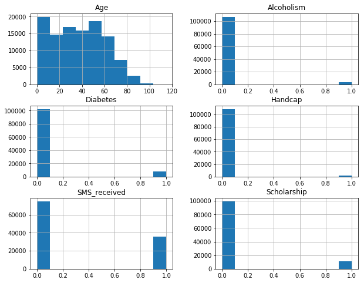

```python
p2.hist(figsize=(10,8))
```

#### replacing the values of no-show column Yes to 1 and No to 0

```python
p2.no_show.replace(to_replace=dict(Yes=1, No=0), inplace=True)
```

```python
p2.describe()
```

|  | Age | Scholarship | Diabetes | Alcoholism | Handcap | SMS_received | no_show |
| --- | --- | --- | --- | --- | --- | --- | --- |
| count | 110327.000000 | 110327.000000 | 110327.000000 | 110327.000000 | 110327.000000 | 110327.000000 | 110327.000000 |
| mean | 37.070753 | 0.098281 | 0.071605 | 0.030382 | 0.018509 | 0.321182 | 0.201927 |
| std | 23.098052 | 0.297695 | 0.257834 | 0.171638 | 0.134782 | 0.466932 | 0.401440 |
| min | 0.000000 | 0.000000 | 0.000000 | 0.000000 | 0.000000 | 0.000000 | 0.000000 |
| 25% | 18.000000 | 0.000000 | 0.000000 | 0.000000 | 0.000000 | 0.000000 | 0.000000 |
| 50% | 37.000000 | 0.000000 | 0.000000 | 0.000000 | 0.000000 | 0.000000 | 0.000000 |
| 75% | 55.000000 | 0.000000 | 0.000000 | 0.000000 | 0.000000 | 1.000000 | 0.000000 |
| max | 115.000000 | 1.000000 | 1.000000 | 1.000000 | 1.000000 | 1.000000 | 1.000000 |

### define the yes and no variables to can do the analysis easily.

```python
pyes = p2.no_show == True
pno = p2.no_show == False
```

### Question 1 what is the gender that have the highest percentage of no show?

#### Drow a histogram for that

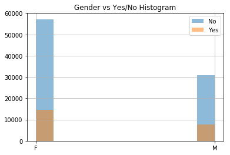

```python
p2.Gender[pno].hist(alpha=0.5 , label='No');
p2.Gender[pyes].hist(alpha = 0.5 , label='Yes')
plt.title('Gender vs Yes/No Histogram')
plt.legend()
```

```python
p2.Gender.value_counts()
```

```
F    71730
M    38597
Name: Gender, dtype: int64
```

### Question 2 does the Age effecting for no_show or not?

#### Drow a histogram for that

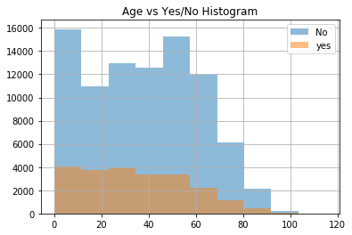

```python
p2.Age[pno].hist(alpha=0.5 , label='No');
p2.Age[pyes].hist(alpha=0.5 , label='yes');
plt.title('Age vs Yes/No Histogram')
plt.legend()
```

#### Drow a scatter for that

```
Text(0.5,1,'Yes/No (No_show) Vs Age')
```

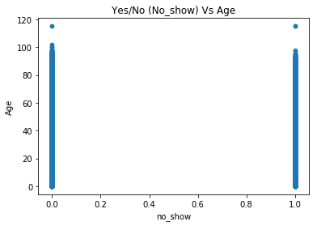

```python
p2.plot.scatter(x='no_show',y='Age');
plt.title('Yes/No (No_show) Vs Age')
```

### Question 3 does the scholarship effecting the no_show?

#### Drow a histogram for that

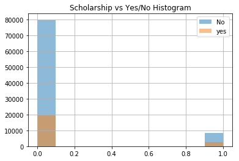

```python
p2.Scholarship[pno].hist(alpha=0.5 , label='No');
p2.Scholarship[pyes].hist(alpha=0.5 , label='yes');
plt.title('Scholarship vs Yes/No Histogram')
plt.legend()
```

```
Text(0.5,1,' Yes/No Vs Scholarship scatter')
```

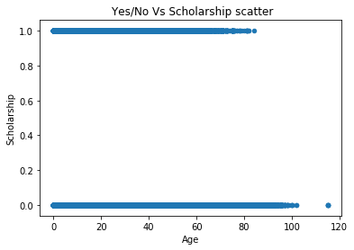

```python
p2.plot.scatter(x='Age',y='Scholarship')
plt.title(' Yes/No Vs Scholarship scatter')
```

### Question 4 does sms have huge impact on showing?

#### Drow a histogram for that

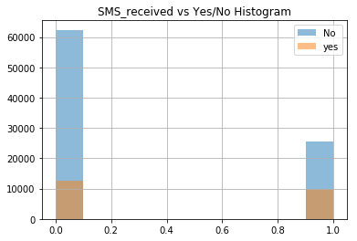

```python
p2.SMS_received[pno].hist(alpha=0.5 , label='No');
p2.SMS_received[pyes].hist(alpha=0.5 , label='yes');
plt.title('SMS_received vs Yes/No Histogram')
plt.legend()
```

### Question 5 which illness type have the highest no-show ratio?

#### Drow a histogram for Diabetes

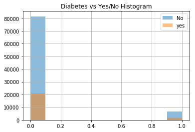

```python
p2.Diabetes[pno].hist(alpha=0.5 , label='No');
p2.Diabetes[pyes].hist(alpha=0.5 , label='yes');
plt.title('Diabetes vs Yes/No Histogram')


plt.legend()
```

#### Freq or bar plot to calculate ratios

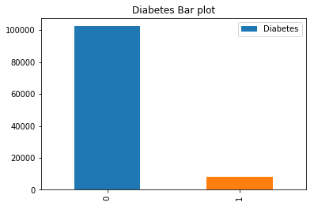

```python
p2['Diabetes'].value_counts().plot.bar();
plt.title('Diabetes Bar plot')
plt.legend()
```

#### Drow a histogram for Alcholism

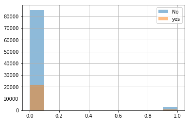

```python
p2.Alcoholism[pno].hist(alpha=0.5 , label='No');
p2.Alcoholism[pyes].hist(alpha=0.5 , label='yes');
plt.legend()
```

#### Freq or bar plot to calculate ratios

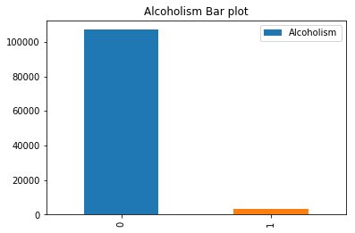

```python
p2['Alcoholism'].value_counts().plot.bar();
plt.title('Alcoholism Bar plot')
plt.legend();
```

#### Drow a histogram for Handcap

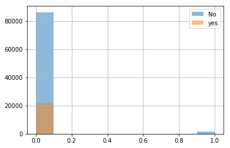

```python
p2.Handcap[pno].hist(alpha=0.5 , label='No');
p2.Handcap[pyes].hist(alpha=0.5 , label='yes');
plt.legend()
```

#### Freq or bar plot to calculate ratios

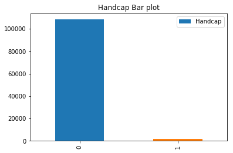

```python
p2['Handcap'].value_counts().plot.bar();
plt.title('Handcap Bar plot')
plt.legend()
```

## Conclusions

I have started with cleaning the date. Then, I have replaced the no_show values yes to 1 and no to 0, Then i have created pyes and pno to do the analsis easier.

### Limitations:

there are some limitations in the data but the most important ones:

##### 1) most of the columns are eaither one or zero so that it cant be visualized will.

##### 2) the ScheduledDay and AppointmentDay are not having the same values so that i cant use them in my analysis.

```python
from subprocess import call
call(['python', '-m', 'nbconvert', 'Investigate_a_Dataset.ipynb'])
```

```
0
```